# Data Science Capstone - Johns Hopkins - Milestone Week 2

Luccas Betton

2023-07-19

# 1. Summary

This report presents the Data Science Capstone - Week 2 Milestone Report. The motivations for this report are:

1. Demonstrate the data was downloaded successfully.
2. Create a basic report of summary statistics about the data sets.
3. Report interesting findings.
4. Get feedback on project plans for creating a prediction algorithm and Shiny app.

The criteria for report evaluation are:

1. Demonstrate that you’ve downloaded the data and have successfully loaded it in.
2. Create a basic report of summary statistics about the data sets.
3. Report any interesting findings that you amassed so far.
4. Get feedback on your plans for creating a prediction algorithm and Shiny app.

# 2. Project Goals

The main goal for this project is to create an application with smart predictive text model making easier to the user for typing and building texts, as we have in our mobile phone, e-mails, and so on.

# 3. Upload Data

Large databases comprising of text in a target language are commonly used when generating language models for various purposes. In this exercise, it is used the English database from different sources in order to predict the next word. The three data sources are:

- Blogs
- News
- Twitter

## 3.1 Library

First of all, all libraries are necessary loaded.

```r
packages <- c("stringr","ggplot2", "dplyr", "tibble", "qdap", "tidytext", "wordcloud2","forcats","tidyr","htmlwidgets", "sweary","webshot") #list of all packages
install.packages(setdiff(packages, rownames(installed.packages()))) #Install package if necessary
lapply(packages, require, character.only = TRUE)
```

## 3.2 Data Download

Download data from URl SwiftKey if files txt don’t exists in the current working directory.

```r
#file path for the three data sources
filepath_news <- "./final/en_US/en_US.news.txt"
filepath_blogs <- "./final/en_US/en_US.blogs.txt"
filepath_twitter <- "./final/en_US/en_US.twitter.txt"

if(!(file.exists(filepath_news)*file.exists(filepath_blogs)*file.exists(filepath_twitter))){
    if(!file.exists("./Coursera-SwiftKey.zip")){
        fileURL <- "https://d396qusza40orc.cloudfront.net/dsscapstone/dataset/Coursera-SwiftKey.zip"
        download.file(fileURL, destfile = "Coursera-SwiftKey.zip", method = "curl")
    }
    unzip("./Coursera-SwiftKey.zip")
}
```

The txt files are read and stores in different variables.

```r
Connec <- file(filepath_news,"rb")
News_RD <- readLines(Connec, skipNul = TRUE) #Raw data for News data source
close(Connec)

Connec <- file(filepath_blogs,"r")
Blog_RD <- readLines(Connec,skipNul = TRUE) #Raw data for Blog data source
close(Connec)

Connec <- file(filepath_twitter,"rb")
Twitter_RD <- readLines(Connec, skipNul = TRUE) #Raw data for Twitter data source
close(Connec)
```

## 4 Sample Data

Since the files have a great amount of data, we sampled randomly 10% for News and for Blogs Data, and 2.5% for Twitter data. The sampling percentage for Twitter was lower because probably this source it will present much more slang, bad words, misspelling and so on.

```r
set.seed(1990)
sample_factors = c(0.1,0.1,0.025)
News_RD_Spl <- News_RD[sample(1:length(News_RD),sample_factors[1]*length(News_RD))] #Sample Data from News Data
Blog_RD_Spl <- Blog_RD[sample(1:length(Blog_RD),sample_factors[2]*length(Blog_RD))] #Sample Data from Blog Data
Twitter_RD_Spl <- Twitter_RD[sample(1:length(Twitter_RD),sample_factors[3]*length(Twitter_RD))] #Sample Data from Twitter Data

#Combine sampled data
RD_Spl <- c(News_RD_Spl,Blog_RD_Spl,Twitter_RD_Spl) #Sampled Raw Data

#Storage Raw Data Sampled
write.table(RD_Spl, file =  "./RawData_Sample.txt", quote = FALSE, sep = "", row.names = FALSE, col.names = FALSE)
```

# 5 Cleaning Data

The cleaning process was performed doing the following steps:

- Transform characters in lowercase
- Remove URL strings
- Remove Non Ascii characters
- Remove punctuation, expect for apostrophe
- Filter out texts with less than 4 words

```r
TD_Spl <- RD_Spl #Copy Raw Data to start cleaning process
TD_Spl <- tolower(TD_Spl) #Transform all characters in lowercase
TD_Spl <- rm_url(TD_Spl) #Remove URL strings
TD_Spl <- rm_non_ascii(TD_Spl) #Remove non ASCII words
TD_Spl <- gsub(".*?($|'|[^[:punct:]]).*?","\\1", TD_Spl) #Remove punctuation expect for apostrophe
TD_Spl <- TD_Spl[which(str_count(TD_Spl,'\\W+')>=4)] #Filter out texts with less than 4 words

TD_Spl_DF <- tibble(Text = TD_Spl) #Tranform Data for dataframe
```

Other cleaning processes were performed when the data was tokenized, that were:

- Remove stop words
- Remove profanity
- Remove numbers

It was used the databases for stop_word from tidytext library and swear_words from sweary for removing stop words and profanity, respectively.

```r
data("stop_words")
data("swear_words")
swear_words = filter(swear_words,language == "en") #Filter only for English swear words
```

## 6. N-Grams

### 6.1 Unigrams

For unigrams it was evaluated the words frequency without filtering stop words and also with stop words.

```r
TD_1gram <- unnest_tokens(TD_Spl_DF, Gram, input = Text, token = "ngrams", n = 1) #Unigram data frame
TD_1gram <- filter(TD_1gram,!str_detect(Gram, "\\d+")) # filter out numbers
TD_1gram <- anti_join(TD_1gram,swear_words, join_by(Gram == word)) # Filter out bad words

TD_1gram_Full <- TD_1gram #data frame with stop words
save(TD_1gram_Full,file="TD_1gram_Full.Rda") #Save data frame with unigrams with stop words

TD_1gram_WoutSw <- anti_join(TD_1gram,stop_words, join_by(Gram == word)) #data frame without stop words
save(TD_1gram_WoutSw,file="TD_1gram_WoutSw.Rda") #Save data frame with unigrams without stop words
```

Next, calculated quantity and frequency for each word.

```r
WordCnt_1gram_Full <- TD_1gram_Full %>%
  group_by_all() %>%
  count() #Group and count duplicate words
WordCnt_1gram_Full <- WordCnt_1gram_Full %>% arrange(desc(n)) #Order
WordCnt_1gram_Full$freq <- WordCnt_1gram_Full$n*100/sum(WordCnt_1gram_Full$n)
WordCnt_1gram_Full$cumfreq <- cumsum(WordCnt_1gram_Full$freq)
save(WordCnt_1gram_Full,file="WordCnt_1gram_Full.Rda") #Save data frame with unigrams qty and freq

WordCnt_1gram_WoutSw <- TD_1gram_WoutSw %>%
  group_by_all() %>%
  count()
WordCnt_1gram_WoutSw <- WordCnt_1gram_WoutSw %>% arrange(desc(n))
WordCnt_1gram_WoutSw$freq <- with(WordCnt_1gram_WoutSw,WordCnt_1gram_WoutSw$n*100/sum(WordCnt_1gram_WoutSw$n))
save(WordCnt_1gram_WoutSw,file="WordCnt_1gram_WoutSw.Rda") #Save data frame with unigrams qty and freq
```

### 6.2 Bigram

As for unigrams, it was evaluated the words frequency without filtering stop words and also with stop words.

```r
TD_2gram <- unnest_tokens(TD_Spl_DF, Gram, input = Text, token = "ngrams", n = 2)
TD_2gram <- filter(TD_2gram,!str_detect(Gram, "\\d+")) #Filter out numbers
TD_2gram <- separate(TD_2gram,Gram,c("Gram1", "Gram2"),sep = " ") # Split in two Grams
TD_2gram <- TD_2gram %>% filter(!(Gram1 %in% swear_words$word | Gram2 %in% swear_words$word)) #Filter out bad words
save(TD_2gram,file="TD_2gram.Rda")

WordCnt_2gram <- TD_2gram %>%
  group_by_all() %>%
  count()
WordCnt_2gram <- WordCnt_2gram %>% arrange(desc(n))
WordCnt_2gram$freq <- WordCnt_2gram$n*100/sum(WordCnt_2gram$n)
WordCnt_2gram$cumfreq <- cumsum(WordCnt_2gram$freq)
#nrow(filter(WordCnt_2gram,n>1))/nrow(WordCnt_2gram)*100 #Observations with more than one appearence
#nrow(filter(WordCnt_2gram,cumfreq<=50))/nrow(WordCnt_2gram)*100
save(WordCnt_2gram,file="WordCnt_2gram.Rda")
#load(file='WordCnt_2gram.Rda')

#TD_2gram Without any stop words
TD_2gram_WoutSw <- TD_2gram %>%
  filter(!Gram1 %in% stop_words$word) %>%
  filter(!Gram2 %in% stop_words$word)
save(TD_2gram_WoutSw,file="TD_2gram_WoutSw.Rda")
#load(file='TD_2gram_Spl_FullFilt.Rda')
WordCnt_2gram_WoutSw <- TD_2gram_WoutSw %>%
  group_by_all() %>%
  count()
WordCnt_2gram_WoutSw <- WordCnt_2gram_WoutSw %>% arrange(desc(n))
WordCnt_2gram_WoutSw$freq <- with(WordCnt_2gram_WoutSw,WordCnt_2gram_WoutSw$n*100/sum(WordCnt_2gram_WoutSw$n))
WordCnt_2gram_WoutSw$cumfreq <- cumsum(WordCnt_2gram_WoutSw$freq)
save(WordCnt_2gram_WoutSw,file="WordCnt_2gram_WoutSw.Rda")
#load(file='WordCnt_2gram_WoutSw.Rda')
```

### 6.3 Trigram

Trigrams it was only applied filtering for stop words when all the words were stop words.

```r
TD_3gram <- unnest_tokens(TD_Spl_DF, Gram, input = Text, token = "ngrams", n = 3)
TD_3gram <- filter(TD_3gram,!str_detect(Gram, "\\d+"))
TD_3gram <- TD_3gram %>% separate(Gram,c("Gram1", "Gram2","Gram3"),sep = " ")
TD_3gram <- TD_3gram %>% filter(!(Gram1 %in% swear_words$word | Gram2 %in% swear_words$word | Gram3 %in% swear_words$word)) #Filtered when all words are stopwords
TD_3gram <- TD_3gram %>% filter(!(Gram1 %in% stop_words$word & Gram2 %in% stop_words$word & Gram3 %in% stop_words$word))  #Filter bad words
save(TD_3gram,file="TD_3gram.Rda")

WordCnt_3gram <- TD_3gram %>%
  group_by_all() %>%
  count()
WordCnt_3gram <- WordCnt_3gram %>% arrange(desc(n))
WordCnt_3gram$freq <- WordCnt_3gram$n*100/sum(WordCnt_3gram$n)
WordCnt_3gram$cumfreq <- cumsum(WordCnt_3gram$freq)
save(WordCnt_3gram,file="WordCnt_3gram.Rda")
#load(file='WordCnt_3gram.Rda')
```

### 6.4 Quadrigram

Quadrigram it was only applied filtering for stop words when all the words were stop words.

```r
TD_4gram <- unnest_tokens(TD_Spl_DF, Gram, input = Text, token = "ngrams", n = 4)
TD_4gram <- filter(TD_4gram,!str_detect(Gram, "\\d+"))
TD_4gram <- TD_4gram %>% separate(Gram,c("Gram1", "Gram2","Gram3","Gram4"),sep = " ")
TD_4gram <- TD_4gram %>% filter(!(Gram1 %in% swear_words$word | Gram2 %in% swear_words$word | Gram3 %in% swear_words$word | Gram4 %in% swear_words$word)) #Filtered when any word are badword
TD_4gram <- TD_4gram %>% filter(!(Gram1 %in% stop_words$word & Gram2 %in% stop_words$word & Gram3 %in% stop_words$word & Gram4 %in% stop_words$word))  #Filter if all words are stop words
save(TD_4gram,file="TD_4gram.Rda")

WordCnt_4gram <- TD_4gram %>%
  group_by_all() %>%
  count()
WordCnt_4gram <- WordCnt_4gram %>% arrange(desc(n))
WordCnt_4gram$freq <- with(WordCnt_4gram,WordCnt_4gram$n*100/sum(WordCnt_4gram$n))
WordCnt_4gram$cumfreq <- cumsum(WordCnt_4gram$freq)
#nrow(filter(WordCnt_4gram,n>1))/nrow(WordCnt_4gram)*100 #Observations with more than one appearence
#nrow(filter(WordCnt_4gram,cumfreq<=50))/nrow(WordCnt_4gram)*100
save(WordCnt_4gram,file="WordCnt_4gram.Rda")
```

# 4. Exploratory Analysis

## 4.1 DataBase Structure

Summary table for each file - Blog, News and Twitter. It was calculated amount of texts (observations) per data source, quantity of words and characters per text, and their averages per data source.

```r
Source_Data <- c("Blogs","News","Twitter") #Source of data
Sizes_Data <- c(length(Blog_RD),length(News_RD),length(Twitter_RD )) #Texts per data source
Word_Data <- c(sum(str_count(Blog_RD,'\\W+')),sum(str_count(News_RD,'\\W+')),sum(str_count(Twitter_RD ,'\\W+'))) #Qty of words per source of data
Char_Data <- c(sum(nchar(Blog_RD)),sum(nchar(News_RD)),sum(nchar(Twitter_RD ))) #Qty  of characters per data source

Summary_Table <- data.frame(Source_Data,Sizes_Data,Word_Data,Char_Data,round(Word_Data/Sizes_Data),round(Char_Data/Sizes_Data))
colnames(Summary_Table) <- c("Data Source", "Lines","Words",'Characters',"Avg Word per line","Avg Char per line")
```

As it was expected Blogs and News are texts much higher than Twitter. It is known that Twitter has limitation of characters per post, but the summary table shows that this platform is used for smaller text, average around 70 characters, far from the limits, in the past 140 characters and now 280 characters.

```r
Summary_Table
```

```
##   Data Source   Lines    Words Characters Avg Word per line Avg Char per line
## 1       Blogs  899288 38216886  206824509                42               230
## 2        News 1010242 35708833  203223159                35               201
## 3     Twitter 2360148 30433493  162122861                13                69
```

Quantity of words per text for each data source shows also the tendency related before.

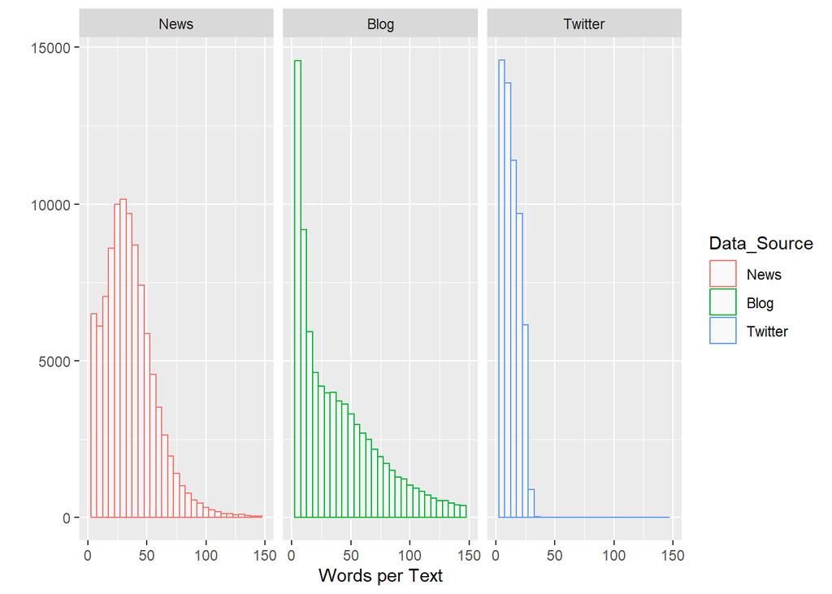

```r
#Frequency data_Frame words per line
FreqWord_News_Spl <- data.frame(str_count(News_RD_Spl,'\\W+'),factor("News"))
colnames(FreqWord_News_Spl) <- c("Words","Data_Source")

FreqWord_Blog_Spl <- data.frame(str_count(Blog_RD_Spl,'\\W+'),factor("Blog"))
colnames(FreqWord_Blog_Spl) <- c("Words","Data_Source")

FreqWord_Twitter_Spl <- data.frame(str_count(Twitter_RD_Spl,'\\W+'),factor("Twitter"))
colnames(FreqWord_Twitter_Spl) <- c("Words","Data_Source")

FreqWord_Spl <- bind_rows(FreqWord_News_Spl, FreqWord_Blog_Spl ,FreqWord_Twitter_Spl)

ggplot(FreqWord_Spl,aes(x=Words, color=Data_Source))+geom_histogram(binwidth = 5, fill = "white", alpha = 0.5, position = 'identity')+xlim(0,150)+facet_wrap(.~Data_Source)+xlab("Words per Text")+ylab("")
```

## 4.2 Unigrams

Unigrams data frame with stop words as it was expected presented a majority of stop words in the top 50 words observed.

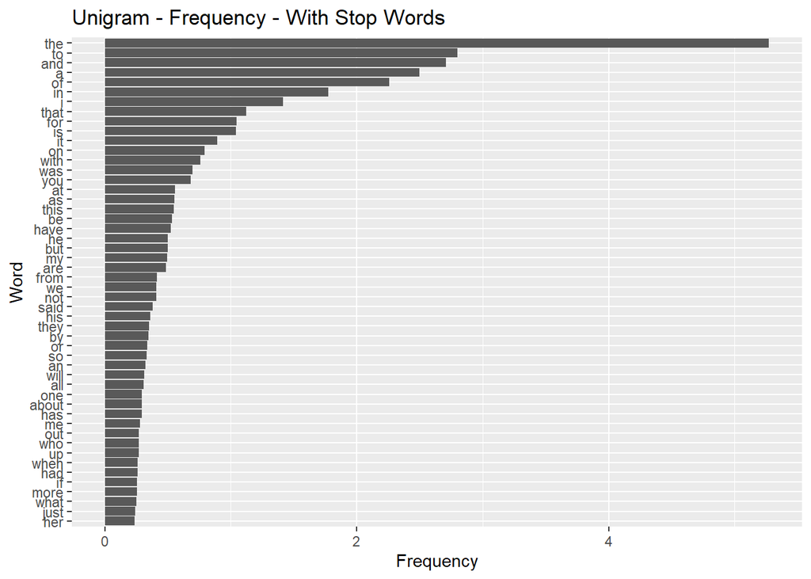

```r
max_plot <- 50
plot_df <- WordCnt_1gram_Full[1:max_plot,]
ggplot(WordCnt_1gram_Full[1:max_plot,],aes(x = freq, y = fct_reorder(Gram,freq)))+geom_col()+xlab("Frequency")+ylab("Word")+ggtitle("Unigram - Frequency - With Stop Words")
```

```r
ggsave("Colunms_1gram_Full.png",plot = last_plot())
```

Unigrams data frame without stopwords. The most frequent words were “time”, “people”, “day” and “love”.

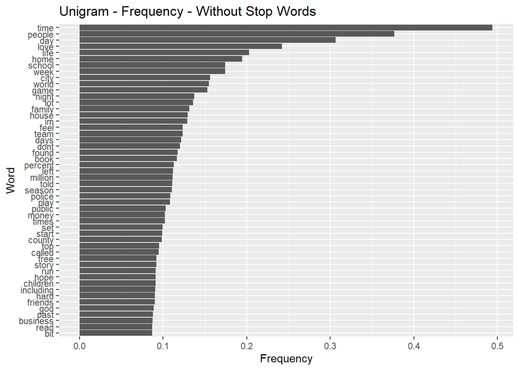

```r
max_plot <- 50
ggplot(WordCnt_1gram_WoutSw[1:max_plot,],aes(x = freq, y = fct_reorder(Gram,freq)))+geom_col()+xlab("Frequency")+ylab("Word")+ggtitle("Unigram - Frequency - Without Stop Words")
```

```r
ggsave("Colunms_1gram_WoutStopWord.png",plot = last_plot())
```

Words Clouds for Unigrams with stop words.

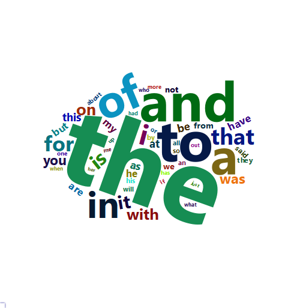

```r
max_cloud <- 50
wd_cloud1gram <- wordcloud2(WordCnt_1gram_Full[1:max_cloud,], color = 'random-dark', size = 1)
saveWidget(wd_cloud1gram,"wordcloud_1gram_Full.html",selfcontained = F)
webshot("wordcloud_1gram_Full.html","wordcloud_1gram_Full.png", delay =5, vwidth = 500, vheight=500) # changed to png
```

Words Clouds for Unigrams without stop words.

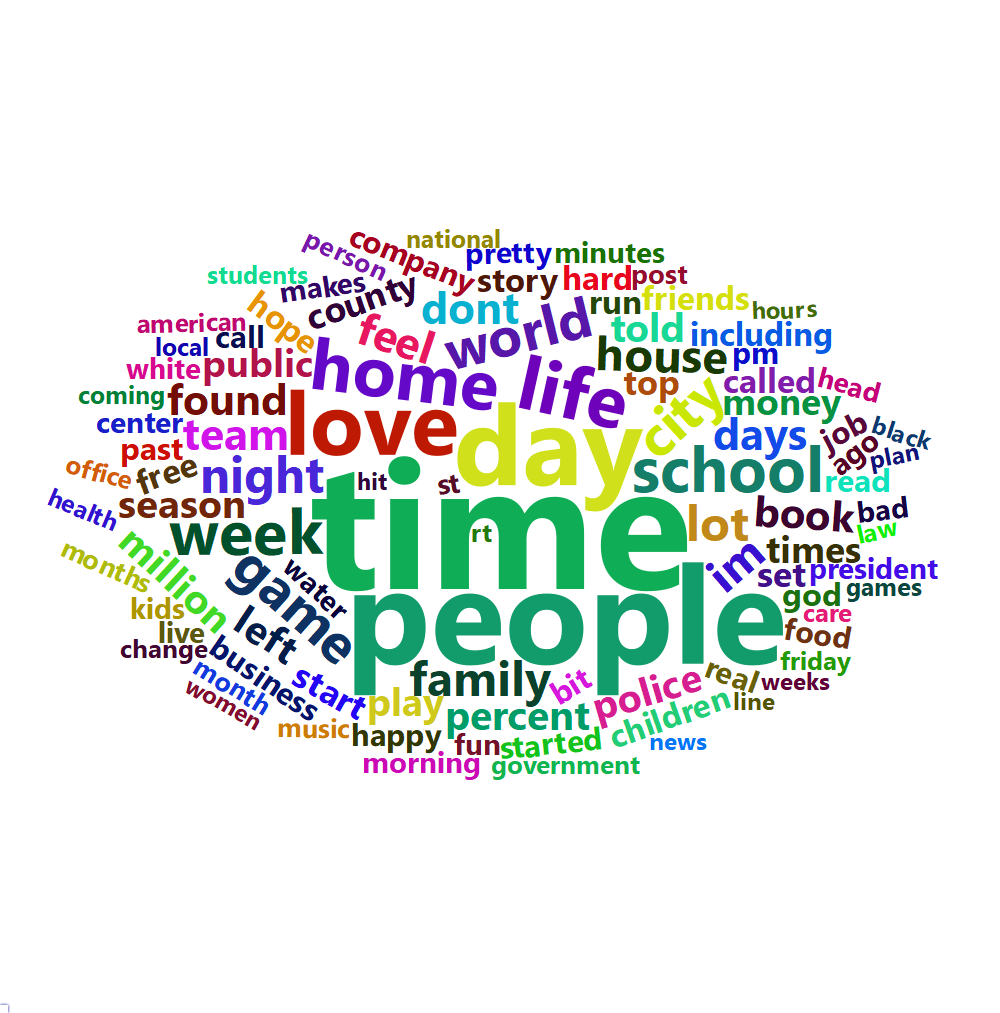

```r
max_cloud <- 100
wd_cloud1gram_WoutSw <- wordcloud2(WordCnt_1gram_WoutSw[1:max_cloud,], color = 'random-dark', size = 1)
saveWidget(wd_cloud1gram_WoutSw,"wordcloud_1gram_WoutSw.html",selfcontained = F)
webshot("wordcloud_1gram_WoutSw.html","wordcloud_1gram_WoutSw.png", delay =5, vwidth = 1000, vheight=1000) # changed to png
```

## 4.3 Bigrams

As in the unigrams the bigrams data with stop words presented mainly only stop words.

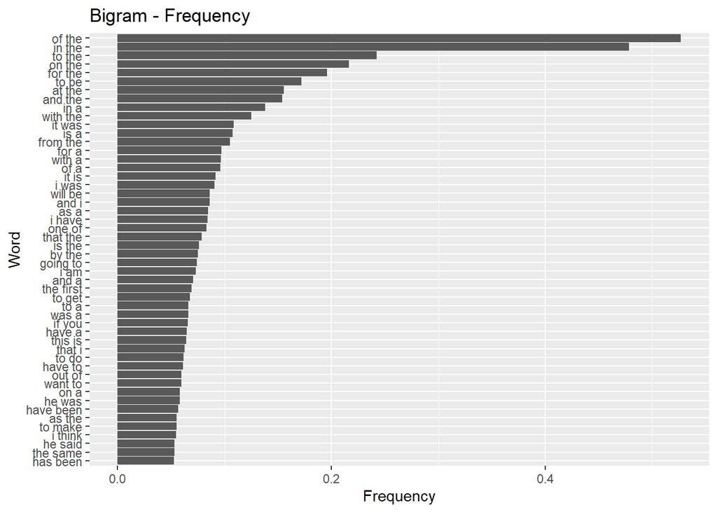

```r
max_plot <- 50
plot_df <- WordCnt_2gram[1:max_plot,]
plot_df <- plot_df %>% unite(Gram, c("Gram1", "Gram2"),sep = " ")
ggplot(mutate(plot_df,Gram = reorder(Gram,n)),aes(x = freq, y = Gram))+geom_col()+xlab("Frequency")+ylab("Word")+ggtitle("Bigram - Frequency")
```

```r
ggsave("Columns_Bigram.png",plot = last_plot())
```

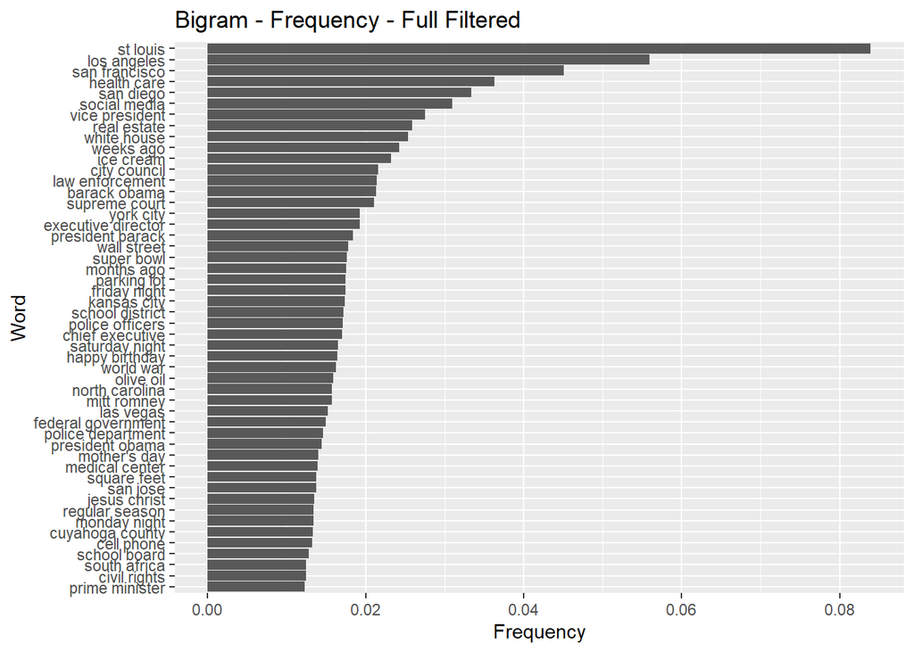

```r
max_plot <- 50
plot_df <- WordCnt_2gram_WoutSw[1:max_plot,]
plot_df <- plot_df %>% unite(Gram, c("Gram1", "Gram2"),sep = " ")
ggplot(mutate(plot_df,Gram = reorder(Gram,n)),aes(x = freq, y = Gram))+geom_col()+xlab("Frequency")+ylab("Word")+ggtitle("Bigram - Frequency - Full Filtered")
```

Wordcloud for bigrams with stop words.

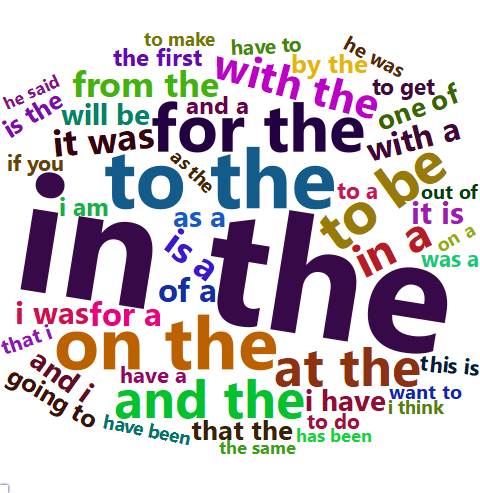

```r
max_cloud <- 50
plot_cloud_df <- WordCnt_2gram[1:max_cloud,]
plot_cloud_df <- plot_cloud_df %>% unite(Gram, c("Gram1", "Gram2"),sep = " ")
wd_cloud2gram <- wordcloud2(plot_cloud_df, color = 'random-dark', size = 1)
#wd_cloud2gram
saveWidget(wd_cloud2gram,"wordcloud_2gram.html",selfcontained = F)
webshot("wordcloud_2gram.html","wordcloud_2gram.png", delay =5, vwidth = 480, vheight=480)
```

Wordcloud for bigrams without stop words.

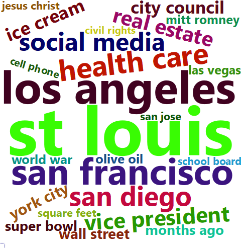

```r
max_cloud <- 50
plot_cloud_df <- WordCnt_2gram_WoutSw[1:max_cloud,]
plot_cloud_df <- plot_cloud_df %>% unite(Gram, c("Gram1", "Gram2"),sep = " ")
wd_cloud2gram <- wordcloud2(plot_cloud_df, color = 'random-dark', size = 0.75)
#wd_cloud2gram
saveWidget(wd_cloud2gram,"wordcloud_2gram.html",selfcontained = F)
webshot("wordcloud_2gram.html","wordcloud_2gram.png", delay =5, vwidth = 480, vheight=480)
```

## 4.4 Trigram

Trigrams with more appearance.

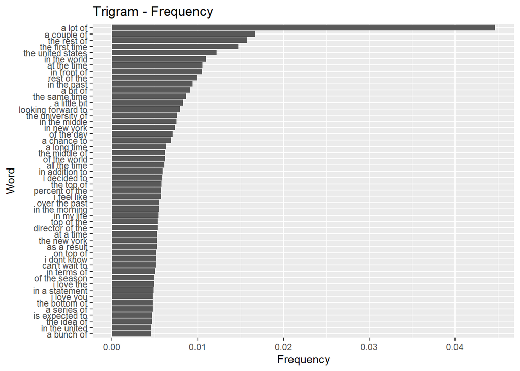

```r
max_plot <- 50
plot_df <- WordCnt_3gram[1:max_plot,]
plot_df <- plot_df %>% unite(Gram, c("Gram1", "Gram2","Gram3"),sep = " ")
ggplot(mutate(plot_df,Gram = reorder(Gram,n)),aes(x = freq, y = Gram))+geom_col()+xlab("Frequency")+ylab("Word")+ggtitle("Trigram - Frequency")
```

```r
ggsave("Columns_Trigram.png",plot = last_plot())
```

Word cloud for trigram.

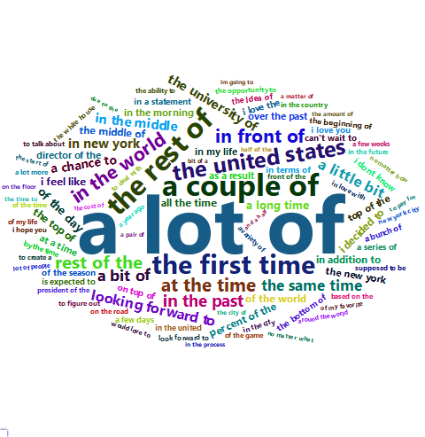

```r
max_cloud <- 100
plot_cloud_df <- WordCnt_3gram[1:max_cloud,]
plot_cloud_df <- plot_cloud_df %>% unite(Gram, c("Gram1", "Gram2","Gram3"),sep = " ")
wd_cloud3gram <- wordcloud2(plot_cloud_df, color = 'random-dark', size = 0.5)
#wd_cloud3gram
saveWidget(wd_cloud3gram,"wordcloud_3gram.html",selfcontained = F)
webshot("wordcloud_3gram.html","wordcloud_3gram.png", delay =5, vwidth = 480, vheight=480)
```

## 4.5 Quadrigram

Quadrigram with more appearance.

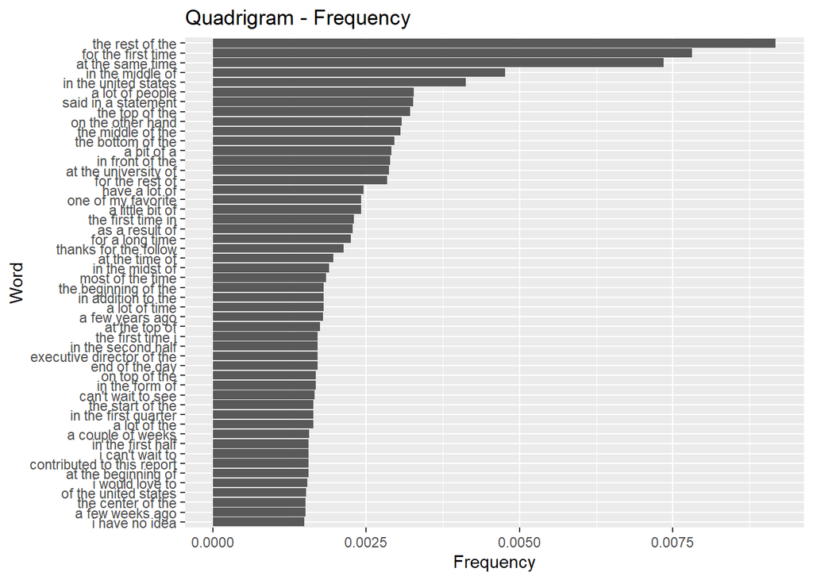

```r
max_plot <- 50
plot_df <- WordCnt_4gram[1:max_plot,]
plot_df <- plot_df %>% unite(Gram, c("Gram1", "Gram2","Gram3","Gram4"),sep = " ")
ggplot(mutate(plot_df,Gram = reorder(Gram,n)),aes(x = freq, y = Gram))+geom_col()+xlab("Frequency")+ylab("Word")+ggtitle("Quadrigram - Frequency")
```

```r
ggsave("Columns_Quadrigram.png",plot = last_plot())
```

Word cloud for quadrigram.

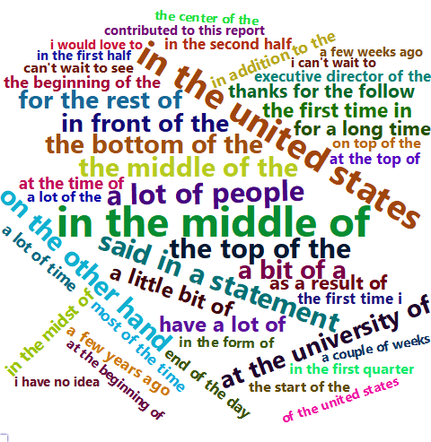

```r
max_cloud <- 50
plot_cloud_df <- WordCnt_4gram[1:max_cloud,]
plot_cloud_df <- plot_cloud_df %>% unite(Gram, c("Gram1", "Gram2","Gram3","Gram4"),sep = " ")
wd_cloud4gram <- wordcloud2(plot_cloud_df, color = 'random-dark', size = 0.5)
saveWidget(wd_cloud4gram,"wordcloud_4gram.html",selfcontained = F)
webshot("wordcloud_4gram.html","wordcloud_4gram.png", delay =5, vwidth = 480, vheight=480)
```

## 4.6 Summary N-Grams

The following table shows the total amount of grams, % of grams with more than one appearance and % of grams that cover 50% of words.

```r
NGram_length <- c(length(WordCnt_1gram_Full$n),length(WordCnt_2gram$n),length(WordCnt_3gram$n),length(WordCnt_4gram$n))
Words_1app <- c(nrow(filter(WordCnt_1gram_Full,n>1))/nrow(WordCnt_1gram_Full)*100)
Words_50freq <- c(nrow(filter(WordCnt_1gram_Full,cumfreq<=50))/nrow(WordCnt_1gram_Full)*100)
Words_1app <- c(Words_1app,nrow(filter(WordCnt_2gram,n>1))/nrow(WordCnt_2gram)*100)
Words_50freq <- c(Words_50freq,nrow(filter(WordCnt_2gram,cumfreq<=50))/nrow(WordCnt_2gram)*100)
Words_1app <- c(Words_1app,nrow(filter(WordCnt_3gram,n>1))/nrow(WordCnt_3gram)*100)
Words_50freq <- c(Words_50freq,nrow(filter(WordCnt_3gram,cumfreq<=50))/nrow(WordCnt_3gram)*100)
Words_1app <- c(Words_1app,nrow(filter(WordCnt_4gram,n>1))/nrow(WordCnt_4gram)*100)
Words_50freq <- c(Words_50freq,nrow(filter(WordCnt_4gram,cumfreq<=50))/nrow(WordCnt_4gram)*100)

Gram_List <- c("Unigram","Bigram","Trigram","Quadrigram") #Source of data
SumGram_Table <- data.frame(Gram_List,NGram_length,round(Words_1app,1),round(Words_50freq,1))
colnames(SumGram_Table) <- c("N-Gram", "Total Qty Grams",  "% Gram More One app","% of Grams cover 50%")
```

Interesting to see that even for unigrams only 46% appears more than one time in all data sampled, and this reduces for the other grams. Also, only 2% of bigrams cover 50% of all the bigrams found.

```r
SumGram_Table
```

```
##       N-Gram Total Qty Grams % Gram More One app % of Grams cover 50%
## 1    Unigram          172651                45.8                  0.1
## 2     Bigram         2141895                25.0                  1.8
## 3    Trigram         4456839                 9.3                 36.6
## 4 Quadrigram         5588590                 3.0                 47.1
```

# 5. Conclusions

All the criteria for this project was fulfilled as it was reported the data download, data cleaning, and exploratory analysis.

For the next steps,the prediction algorithm will evaluate the most frequent phrase constructions based on the user inputs. First, it will evaluate quadrigrams, trigrams, bigrams and finnaly the most common words in the unigram.

One concern is the processing time to look for matching grams in each data frame of n-grams. Probably, it will be necessary to simplify this data in order to achieve a better user experience, maybe reducing the size of data frames only for grams that appear more than one time.